# Practice notebook for regression analysis with NHANES

This notebook will give you the opportunity to perform some regression analyses with the NHANES data that are similar to the analyses done in the week 2 case study notebook.

You can enter your code into the cells that say "enter your code here", and you can type responses to the questions into the cells that say "Type Markdown and Latex".

Note that most of the code that you will need to write below is very similar to code that appears in the case study notebook. You will need to edit code from that notebook in small ways to adapt it to the prompts below.

To get started, we will use the same module imports and read the data in the same way as we did in the case study:

```python
%matplotlib inline
import matplotlib.pyplot as plt
import seaborn as sns
import pandas as pd
import statsmodels.api as sm
import numpy as np

url = "https://raw.githubusercontent.com/kshedden/statswpy/master/NHANES/merged/nhanes_2015_2016.csv"
da = pd.read_csv(url)

# Drop unused columns, drop rows with any missing values.
vars = ["BPXSY1", "RIDAGEYR", "RIAGENDR", "RIDRETH1", "DMDEDUC2", "BMXBMI", "SMQ020", "ALQ110"]
da = da[vars].dropna()
```

```python
da.describe()
```

|  | BPXSY1 | RIDAGEYR | RIAGENDR | RIDRETH1 | DMDEDUC2 | BMXBMI | SMQ020 | ALQ110 |
| --- | --- | --- | --- | --- | --- | --- | --- | --- |
| count | 1473.000000 | 1473.000000 | 1473.000000 | 1473.000000 | 1473.000000 | 1473.000000 | 1473.000000 | 1473.000000 |
| mean | 126.570265 | 52.794297 | 1.705363 | 3.046843 | 3.203666 | 29.960625 | 1.785472 | 1.569586 |
| std | 19.507123 | 18.011332 | 0.456034 | 1.396757 | 1.416350 | 7.382318 | 0.454603 | 0.646435 |
| min | 84.000000 | 20.000000 | 1.000000 | 1.000000 | 1.000000 | 16.400000 | 1.000000 | 1.000000 |
| 25% | 114.000000 | 38.000000 | 1.000000 | 2.000000 | 2.000000 | 24.700000 | 2.000000 | 1.000000 |
| 50% | 124.000000 | 54.000000 | 2.000000 | 3.000000 | 3.000000 | 28.900000 | 2.000000 | 2.000000 |
| 75% | 138.000000 | 68.000000 | 2.000000 | 4.000000 | 4.000000 | 33.700000 | 2.000000 | 2.000000 |
| max | 236.000000 | 80.000000 | 2.000000 | 5.000000 | 9.000000 | 64.600000 | 9.000000 | 9.000000 |

## Question 1:

Use linear regression to relate the expected body mass index (BMI) to a person's age.

```python
# enter your code here
model = sm.OLS.from_formula('BMXBMI ~ RIDAGEYR', data=da)
result = model.fit()
result.summary()
```

OLS Regression Results

| Dep. Variable: | BMXBMI | R-squared: | 0.002 |
| --- | --- | --- | --- |
| Model: | OLS | Adj. R-squared: | 0.001 |
| Method: | Least Squares | F-statistic: | 2.280 |
| Date: | Sun, 27 Sep 2020 | Prob (F-statistic): | 0.131 |
| Time: | 10:44:24 | Log-Likelihood: | -5033.1 |
| No. Observations: | 1473 | AIC: | 1.007e+04 |
| Df Residuals: | 1471 | BIC: | 1.008e+04 |
| Df Model: | 1 |  |  |
| Covariance Type: | nonrobust |  |  |

|  | coef | std err | t | P>\|t\| | [0.025 | 0.975] |
| --- | --- | --- | --- | --- | --- | --- |
| Intercept | 29.1093 | 0.596 | 48.871 | 0.000 | 27.941 | 30.278 |
| RIDAGEYR | 0.0161 | 0.011 | 1.510 | 0.131 | -0.005 | 0.037 |

| Omnibus: | 263.915 | Durbin-Watson: | 2.016 |
| --- | --- | --- | --- |
| Prob(Omnibus): | 0.000 | Jarque-Bera (JB): | 495.303 |
| Skew: | 1.083 | Prob(JB): | 2.79e-108 |
| Kurtosis: | 4.838 | Cond. No. | 173. |

Warnings:  
[1] Standard Errors assume that the covariance matrix of the errors is correctly specified.

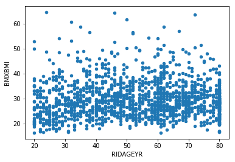

```python
da.plot.scatter(y="BMXBMI",x="RIDAGEYR")
```

```python
print(da.loc[da["RIDAGEYR"] == 20, "BMXBMI"].mean())
print(da.loc[da["RIDAGEYR"] == 40, "BMXBMI"].mean())
```

```
27.92413793103448
29.535999999999998
```

**Q1a.** According to your fitted model, do older people tend to have higher or lower BMI than younger people?

Older People tend to have higher BMI than younger people

**Q1b.** Based your analysis, are you confident that there is a relationship between BMI and age in the population that NHANES represents?

Not confident, since p-value is (0.131) and CI includes zero.

**Q1c.** By how much does the average BMI of a 40 year old differ from the average BMI of a 20 year old?

(40-20)*(0.0161) = 0.322

**Q1d.** What fraction of the variation of BMI in this population is explained by age?

0.002

## Question 2:

Add gender and ethnicity as additional control variables to your linear model relating BMI to age. You will need to recode the ethnic groups based on the values in the codebook entry for RIDRETH1.

```python
# enter your code here
da["RIDRETH1"] = da.RIDRETH1.replace({1: "Mexican American", 2: "Other Hispanic", 3: "Non-Hispanic White", 4: "Non-Hispanic Black", 5: "Other Race - Including Multiracial"}).dropna()
da["RIAGENDR"] = da.RIAGENDR.replace({1: "Male", 2: "Female"}).dropna()


model = sm.OLS.from_formula('BMXBMI ~ RIDAGEYR + RIDRETH1 + RIAGENDR', data=da)
result = model.fit()
result.summary()
```

OLS Regression Results

| Dep. Variable: | BMXBMI | R-squared: | 0.089 |
| --- | --- | --- | --- |
| Model: | OLS | Adj. R-squared: | 0.085 |
| Method: | Least Squares | F-statistic: | 23.80 |
| Date: | Sun, 27 Sep 2020 | Prob (F-statistic): | 5.55e-27 |
| Time: | 10:44:30 | Log-Likelihood: | -4965.8 |
| No. Observations: | 1473 | AIC: | 9946. |
| Df Residuals: | 1466 | BIC: | 9983. |
| Df Model: | 6 |  |  |
| Covariance Type: | nonrobust |  |  |

|  | coef | std err | t | P>\|t\| | [0.025 | 0.975] |
| --- | --- | --- | --- | --- | --- | --- |
| Intercept | 31.6846 | 0.682 | 46.453 | 0.000 | 30.347 | 33.023 |
| RIDRETH1[T.Non-Hispanic Black] | -0.7502 | 0.569 | -1.319 | 0.187 | -1.866 | 0.366 |
| RIDRETH1[T.Non-Hispanic White] | -0.9866 | 0.562 | -1.755 | 0.080 | -2.090 | 0.116 |
| RIDRETH1[T.Other Hispanic] | -1.0388 | 0.628 | -1.654 | 0.098 | -2.271 | 0.193 |
| RIDRETH1[T.Other Race - Including Multiracial] | -5.8381 | 0.588 | -9.920 | 0.000 | -6.992 | -4.684 |
| RIAGENDR[T.Male] | -1.2017 | 0.407 | -2.949 | 0.003 | -2.001 | -0.402 |
| RIDAGEYR | 0.0058 | 0.010 | 0.560 | 0.576 | -0.015 | 0.026 |

| Omnibus: | 256.385 | Durbin-Watson: | 2.032 |
| --- | --- | --- | --- |
| Prob(Omnibus): | 0.000 | Jarque-Bera (JB): | 491.828 |
| Skew: | 1.044 | Prob(JB): | 1.59e-107 |
| Kurtosis: | 4.912 | Cond. No. | 306. |

Warnings:  
[1] Standard Errors assume that the covariance matrix of the errors is correctly specified.

**Q2a.** How did the mean relationship between BMI and age change when you added additional covariates to the model?

**Q2b.** How did the standard error for the regression parameter for age change when you added additional covariates to the model?

It didn't change much, from 0.011 to 0.010

**Q2c.** How much additional variation in BMI is explained by age, gender, and ethnicity that is not explained by age alone?

0.089 - 0.002 =0.087

**Q2d.** What reference level did the software select for the ethnicity variable?

Mexican Americans

**Q2e.** What is the expected difference between the BMI of a 40 year-old non-Hispanic black man and a 30 year-old non-Hispanic black man?

10*0.0058 = 0.058

**Q2f.** What is the expected difference between the BMI of a 50 year-old Mexican American woman and a 50 year-old non-Hispanic black man?

-0.7502 - 1.2017 = -1.9519

## Question 3:

Randomly sample 25% of the NHANES data, then fit the same model you used in question 2 to this data set.

```python
# enter your code here

import pandas as pd
import random


p = 0.25  # 25% of the lines
# keep the header, then take only 25% of lines
# if random from [0,1] interval is greater than 0.01 the row will be skipped
df = pd.read_csv(
         url,
         header=0,
         skiprows=lambda i: i>0 and random.random() > p
)


df["RIDRETH1"] = df.RIDRETH1.replace({1: "Mexican American", 2: "Other Hispanic", 3: "Non-Hispanic White", 4: "Non-Hispanic Black", 5: "Other Race - Including Multiracial"})
df["RIAGENDR"] = df.RIAGENDR.replace({1: "Male", 2: "Female"}).dropna()


model = sm.OLS.from_formula('BMXBMI ~ RIDAGEYR + RIDRETH1 + RIAGENDR', data=df)
result2 = model.fit()
result2.summary()
```

OLS Regression Results

| Dep. Variable: | BMXBMI | R-squared: | 0.046 |
| --- | --- | --- | --- |
| Model: | OLS | Adj. R-squared: | 0.042 |
| Method: | Least Squares | F-statistic: | 11.66 |
| Date: | Sun, 27 Sep 2020 | Prob (F-statistic): | 8.60e-13 |
| Time: | 10:44:39 | Log-Likelihood: | -4865.8 |
| No. Observations: | 1448 | AIC: | 9746. |
| Df Residuals: | 1441 | BIC: | 9782. |
| Df Model: | 6 |  |  |
| Covariance Type: | nonrobust |  |  |

|  | coef | std err | t | P>\|t\| | [0.025 | 0.975] |
| --- | --- | --- | --- | --- | --- | --- |
| Intercept | 29.6414 | 0.677 | 43.811 | 0.000 | 28.314 | 30.969 |
| RIDRETH1[T.Non-Hispanic Black] | 0.1155 | 0.586 | 0.197 | 0.844 | -1.035 | 1.266 |
| RIDRETH1[T.Non-Hispanic White] | -1.0831 | 0.545 | -1.986 | 0.047 | -2.153 | -0.013 |
| RIDRETH1[T.Other Hispanic] | -1.2286 | 0.674 | -1.824 | 0.068 | -2.550 | 0.093 |
| RIDRETH1[T.Other Race - Including Multiracial] | -4.1608 | 0.640 | -6.499 | 0.000 | -5.417 | -2.905 |
| RIAGENDR[T.Male] | -0.5479 | 0.367 | -1.491 | 0.136 | -1.269 | 0.173 |
| RIDAGEYR | 0.0248 | 0.010 | 2.446 | 0.015 | 0.005 | 0.045 |

| Omnibus: | 266.402 | Durbin-Watson: | 1.993 |
| --- | --- | --- | --- |
| Prob(Omnibus): | 0.000 | Jarque-Bera (JB): | 507.631 |
| Skew: | 1.102 | Prob(JB): | 5.88e-111 |
| Kurtosis: | 4.886 | Cond. No. | 303. |

Warnings:  
[1] Standard Errors assume that the covariance matrix of the errors is correctly specified.

**Q3a.** How do the estimated regression coefficients and their standard errors compare between these two models? Do you see any systematic relationship between the two sets of results?

coefficients have changed noticeably; standard errors had minimal change; smaller r squared.

## Question 4:

Generate a scatterplot of the residuals against the fitted values for the model you fit in question 2.

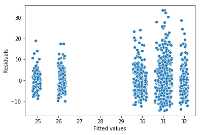

```python
# enter your code here

pp = sns.scatterplot(result.fittedvalues, result.resid)
pp.set_xlabel("Fitted values")
_ = pp.set_ylabel("Residuals")
```

**Q4a.** What mean/variance relationship do you see?

## Question 5:

Generate a plot showing the fitted mean BMI as a function of age for Mexican American men. Include a 95% simultaneous confidence band on your graph.

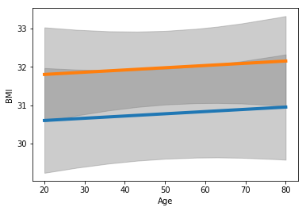

```python
# enter your code here


from statsmodels.sandbox.predict_functional import predict_functional

# Fix certain variables at reference values.  Not all of these
# variables are used here, but we provide them with a value anyway
# to prevent a warning message from appearing.
values = {"RIAGENDR": "Male", "RIDRETH1": "Mexican American"}

# The returned values are the predicted values (pr), the confidence bands (cb),
# and the function values (fv).
pr, cb, fv = predict_functional(result, "RIDAGEYR",
                values=values, ci_method="simultaneous")

ax = sns.lineplot(fv, pr, lw=4)
ax.fill_between(fv, cb[:, 0], cb[:, 1], color='grey', alpha=0.4)
ax.set_xlabel("Age")
_ = ax.set_ylabel("BMI")



values["RIAGENDR"] = "Female"
pr, cb, fv = predict_functional(result, "RIDAGEYR",
  values=values, ci_method="simultaneous")


ax = sns.lineplot(fv, pr, lw=4)
ax.fill_between(fv, cb[:, 0], cb[:, 1], color='grey', alpha=0.4)
ax.set_xlabel("Age")
_ = ax.set_ylabel("BMI")
```

**Q5a.** According to your graph, what is the longest interval starting at year 30 following which the mean BMI could be constant? *Hint:* What is the longest horizontal line starting at age 30 that remains within the confidence band?

50 years

**Q5b.** Add an additional line and confidence band to the same plot, showing the relationship between age and BMI for Mexican American women. At what ages do these intervals not overlap?

They overlap at all ages.

## Question 6:

Use an added variable plot to assess the linearity of the relationship between BMI and age (when controlling for gender and ethnicity).

[output not shown]

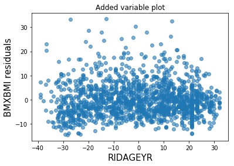

```python
# enter your code here

# This is not part of the main Statsmodels API, so needs to
# be imported separately
from statsmodels.graphics.regressionplots import add_lowess

# This is an equivalent way to fit a linear regression model,
# it needs to be done this way to be able to make the added variable plot
model = sm.GLM.from_formula('BMXBMI ~ RIDAGEYR + RIDRETH1 + RIAGENDR',
                            data=da)
result = model.fit()
result.summary()

fig = result.plot_added_variable("RIDAGEYR")
ax = fig.get_axes()
ax.lines[0].set_alpha(0.2)
_ = add_lowess(ax)
```

**Q6a.** What is your interpretation of the added variable plot?

## Question 7:

Generate a binary variable reflecting whether a person has had at least 12 drinks in their lifetime, based on the ALQ110 variable in NHANES. Calculate the marginal probability, odds, and log odds of this variable for women and for men. Then calculate the odds ratio for females relative to males.

```python
# enter your code here

da['ALQ'] = da.ALQ110.replace({2: 0, 7: np.nan, 9: np.nan})
da["RIAGENDRx"] = da.RIAGENDR.replace({1: "Male", 2: "Female"})

ctab = pd.crosstab(da.RIAGENDRx, da.ALQ).apply(lambda y: y/y.sum(), axis = 1)
ctab
# Calculate marginal probability (for women and men)

# odds (for women and men)

# log odds (for women and men)

# odds ratio for females relative to males
ctab['odds'] = ctab.loc[:,1] / ctab.loc[:,0]
ctab['logit'] = np.log(ctab.odds)
ctab
```

| ALQ RIAGENDRx | 0.0 | 1.0 | odds | logit |
| --- | --- | --- | --- | --- |
| Female | 0.549228 | 0.450772 | 0.820738 | -0.197551 |
| Male | 0.537037 | 0.462963 | 0.862069 | -0.148420 |

**Q7a.** Based on the log odds alone, do more than 50% of women drink alcohol?

**Q7b.** Does there appear to be an important difference between the alcohol use rate of women and men?

no

## Question 8:

Use logistic regression to express the log odds that a person drinks (based on the binary drinking variable that you constructed above) in terms of gender.

```python
# enter your code here


logit = sm.GLM.from_formula('ALQ ~ RIAGENDRx', family = sm.families.Binomial(), data = da)
result = logit.fit()
result.summary()
```

Generalized Linear Model Regression Results

| Dep. Variable: | ALQ | No. Observations: | 1468 |
| --- | --- | --- | --- |
| Model: | GLM | Df Residuals: | 1466 |
| Model Family: | Binomial | Df Model: | 1 |
| Link Function: | logit | Scale: | 1.0000 |
| Method: | IRLS | Log-Likelihood: | -1011.3 |
| Date: | Sun, 27 Sep 2020 | Deviance: | 2022.6 |
| Time: | 10:44:58 | Pearson chi2: | 1.47e+03 |
| No. Iterations: | 4 | Covariance Type: | nonrobust |

|  | coef | std err | z | P>\|z\| | [0.025 | 0.975] |
| --- | --- | --- | --- | --- | --- | --- |
| Intercept | -0.1976 | 0.062 | -3.164 | 0.002 | -0.320 | -0.075 |
| RIAGENDRx[T.Male] | 0.0491 | 0.115 | 0.427 | 0.669 | -0.176 | 0.274 |

**Q8a.** Is there statistical evidence that the drinking rate differs between women and men? If so, in what direction is there a difference?

no, p value is too high and confidence interval contains 0

**Q8b.** Confirm that the log odds ratio between drinking and smoking calculated using the logistic regression model matches the log odds ratio calculated directly in question 6.

NOTE: This should be a typo, as it seems to mean Question 7 instead of 6.

The log odds ratio here matches that which is calculated directly in question 6. (Using the output from print(ctab.logit.Male - ctab.logit.Female), which should be 0.0491)

## Question 9:

Use logistic regression to relate drinking to age, gender, and education.

```python
# enter your code here
da["RIDRETH1"] = da.RIDRETH1.replace({1: "Mexican American", 2: "Other Hispanic", 3: "Non-Hispanic White", 4: "Non-Hispanic Black", 5: "Other Race - Including Multiracial"})
da["RIAGENDR"] = da.RIAGENDR.replace({1: "Male", 2: "Female"}).dropna()
da["DMDEDUC2x"] = da.DMDEDUC2.replace({1: "lt9", 2: "x9_11", 3: "HS", 4: "SomeCollege",
                                       5: "College", 7: np.nan, 9: np.nan})


model = sm.GLM.from_formula("ALQ ~ RIDAGEYR + RIAGENDRx + DMDEDUC2x", family=sm.families.Binomial(), data=da)
result2 = model.fit()
result2.summary()
```

Generalized Linear Model Regression Results

| Dep. Variable: | ALQ | No. Observations: | 1467 |
| --- | --- | --- | --- |
| Model: | GLM | Df Residuals: | 1460 |
| Model Family: | Binomial | Df Model: | 6 |
| Link Function: | logit | Scale: | 1.0000 |
| Method: | IRLS | Log-Likelihood: | -987.65 |
| Date: | Sun, 27 Sep 2020 | Deviance: | 1975.3 |
| Time: | 10:45:04 | Pearson chi2: | 1.47e+03 |
| No. Iterations: | 4 | Covariance Type: | nonrobust |

|  | coef | std err | z | P>\|z\| | [0.025 | 0.975] |
| --- | --- | --- | --- | --- | --- | --- |
| Intercept | -0.4849 | 0.193 | -2.519 | 0.012 | -0.862 | -0.108 |
| RIAGENDRx[T.Male] | 0.0313 | 0.117 | 0.267 | 0.789 | -0.198 | 0.261 |
| DMDEDUC2x[T.HS] | -0.0278 | 0.163 | -0.170 | 0.865 | -0.348 | 0.292 |
| DMDEDUC2x[T.SomeCollege] | 0.1147 | 0.152 | 0.756 | 0.450 | -0.183 | 0.412 |
| DMDEDUC2x[T.lt9] | -0.8479 | 0.176 | -4.814 | 0.000 | -1.193 | -0.503 |
| DMDEDUC2x[T.x9_11] | -0.4496 | 0.190 | -2.367 | 0.018 | -0.822 | -0.077 |
| RIDAGEYR | 0.0090 | 0.003 | 2.975 | 0.003 | 0.003 | 0.015 |

**Q9a.** Which of these predictor variables shows a statistically significant association with drinking?

Age and both education groups who did not graduate high school

**Q9b.** What is the odds of a college educated, 50 year old woman drinking?

-0.4849 + (50*0.0090) = -0.0349 np.exp(-0.0349) = 0.96

If you know that the log odds when comparing two groups is a given value, say 2, and you want to report the odds, you simply exponentiate the log odds to get the odds, e.g. exp(2) is around 7.4.

**Q9c.** What is the odds ratio between the drinking status for college graduates and high school graduates (with no college), holding gender and age fixed?

np.exp(-0.0278)

0.9725828639236711

**Q9d.** Did the regression parameter for gender change to a meaningful degree when age and education were added to the model?

No, it decreased from 0.0491 to 0.0313, and remained non-significant (p-value actually increased).

## Question 10:

Construct a CERES plot for the relationship between drinking and age (using the model that controls for gender and educational attainment).

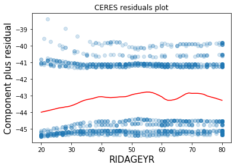

```python
# enter your code here
from statsmodels.graphics.regressionplots import add_lowess

fig = result2.plot_ceres_residuals("RIDAGEYR")
ax = fig.get_axes()[0]
ax.lines[0].set_alpha(0.2)

_ = add_lowess(ax)

# CERES identifies major discrepancies between the fitted model and the population, but evidence for
# small discrepancies is not reliable unless the sample size is very large.
# The CERES technique has the strongest theoretical support.
# Can be useful at identifying possible opportunities for future analysis with additional data,
# but do not identify features that can be claimed with high confidence using the present data.
```

**Q10a.** Does the plot indicate any major non-linearity in the relationship between age and the log odds for drinking?

The plot indicates that drinking rates rise slightly faster between ages of 20-40, with minimal increase from 40-55, a decrease from 55-65, and slight increase and ddecrease from 65-80.